# Compositional covariates

Drew Tyre

5/9/2017

The problem with compositional covariates is that they create multi-collinearity. We’ll simulate the dataset created by Brian Cade to illustrate the problem and explore the different possible fixes.

```r
library(tidyverse)
library(GGally)
```

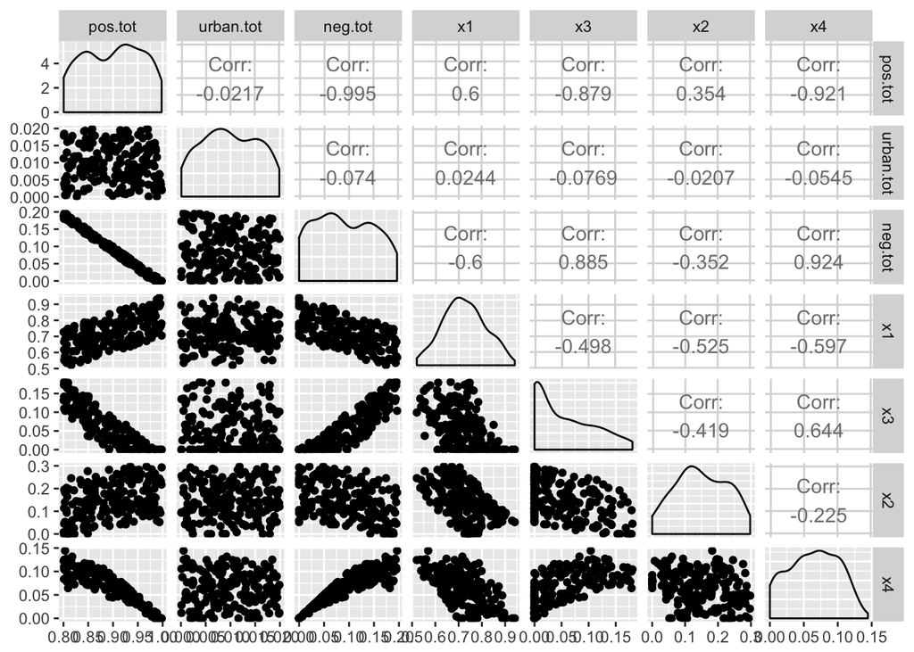

```r
# doesn't matter what this is -- if you use a different number your results will be different from mine.
set.seed(87)
df <- data_frame(
  pos.tot = runif(200,min=0.8,max=1.0),
  urban.tot = pmin(runif(200,min=0.0,max=0.02),1.0 - pos.tot),
  neg.tot = (1.0 - pmin(pos.tot + urban.tot,1)),
  x1= pmax(pos.tot - runif(200,min=0.05,max=0.30),0),
  x3= pmax(neg.tot - runif(200,min=0.0,max=0.10),0),
  x2= pmax(pos.tot - x1 - x3/2,0),
  x4= pmax(1 - x1 - x2 - x3 - urban.tot,0))

ggpairs(df)
```

So there is a near perfect negative correlation between the things sagegrouse like and the things they don’t like, although it gets less bad when considering the individual covariates. In fact, looking at the correlations between just x1 through x4 none of them have correlations bigger than $|0.7|$, so common “rules of thumb” would not exclude them. Now we’ll build up a poisson response, and fit all the models

```r
mean.y <- exp(-5.8 + 6.3*df$x1 + 15.2*df$x2)
df$y <- rpois(200,mean.y)

library(MuMIn)
globalMod <- glm(y ~ x1 + x2 + x3 + x4, data = df, na.action = na.fail, family=poisson())
fits <- dredge(globalMod)
```

```
## Fixed term is "(Intercept)"
```

```r
model.sel(fits)
```

```
## Global model call: glm(formula = y ~ x1 + x2 + x3 + x4, family = poisson(), data = df,
##     na.action = na.fail)
## ---
## Model selection table
##    (Intrc)      x1     x2      x3        x4 df   logLik   AICc  delta
## 4  -6.1660  6.7650 15.230                    3 -379.105  764.3   0.00
## 15  0.5377          8.444  -6.941  -6.71700  4 -378.079  764.4   0.03
## 14  8.8830 -8.4220        -15.200 -15.29000  4 -378.594  765.4   1.06
## 8  -5.6430  6.2340 14.650  -1.068            4 -378.985  766.2   1.84
## 16  2.5030 -1.9850  6.465  -8.879  -8.74200  5 -378.025  766.4   2.03
## 12 -6.1170  6.7160 15.180          -0.09979  4 -379.104  766.4   2.08
## 7   0.3395          8.293 -10.880            3 -392.344  790.8  26.48
## 11  0.3874          9.347         -11.31000  3 -394.048  794.2  29.89
## 6   6.4880 -5.9360        -21.530            3 -440.512  887.1 122.82
## 3  -0.4410         10.580                    2 -457.572  919.2 154.87
```

[output cut: 24 more lines]

Does looking at model averaged coefficients help?

```r
summary(model.avg(fits))
```

```
##
## Call:
## model.avg(object = fits)
##
## Component model call:
## glm(formula = y ~ <16 unique rhs>, family = poisson(), data = df,
##      na.action = na.fail)
##
## Component models:
##        df  logLik    AICc  delta weight
## 12      3 -379.10  764.33   0.00   0.27
## 234     4 -378.08  764.36   0.03   0.27
## 134     4 -378.59  765.39   1.06   0.16
## 123     4 -378.98  766.17   1.84   0.11
## 1234    5 -378.03  766.36   2.03   0.10
## 124     4 -379.10  766.41   2.08   0.10
## 23      3 -392.34  790.81  26.48   0.00
## 24      3 -394.05  794.22  29.89   0.00
## 13      3 -440.51  887.15 122.82   0.00
## 2       2 -457.57  919.21 154.87   0.00
## 14      3 -469.01  944.15 179.81   0.00
## 34      3 -522.94 1051.99 287.66   0.00
## 3       2 -532.38 1068.83 304.49   0.00
## 4       2 -585.45 1174.97 410.63   0.00
## 1       2 -708.35 1420.75 656.42   0.00
## (Null)  1 -711.51 1425.04 660.71   0.00
##
## Term codes:
## x1 x2 x3 x4
##  1  2  3  4
##
## Model-averaged coefficients:
## (full average)
##             Estimate Std. Error Adjusted SE z value Pr(>|z|)
## (Intercept)   -1.061      5.782       5.786   0.183   0.8545
## x1             1.613      5.839       5.844   0.276   0.7826
## x2            10.058      5.856       5.861   1.716   0.0861 .
## x3            -5.267      5.885       5.890   0.894   0.3712
## x4            -5.103      6.001       6.007   0.850   0.3955
##
## (conditional average)
##             Estimate Std. Error Adjusted SE z value Pr(>|z|)
## (Intercept)   -1.061      5.782       5.786   0.183  0.85451
## x1             2.200      6.725       6.730   0.327  0.74372
## x2            11.967      4.238       4.245   2.819  0.00482 **
## x3            -8.322      5.412       5.421   1.535  0.12476
## x4            -8.221      5.691       5.700   1.442  0.14925
## ---
## Signif. codes:  0 '***' 0.001 '**' 0.01 '*' 0.05 '.' 0.1 ' ' 1
##
## Relative variable importance:
##                      x2   x1   x3   x4
## Importance:          0.84 0.73 0.63 0.62
## N containing models:    8    8    8    8
```

## how do we fix the problem?

There are a few possible fixes for compositional covariates

- leave one out. This only really helps when there are two categories. In this case we have left out urban cover, and as a result we have kind of already done it, and it’s not helping.
- Reduce correlations with PCA and then use transformed axes
- use the isometric log ratio transformation

### Using PCA

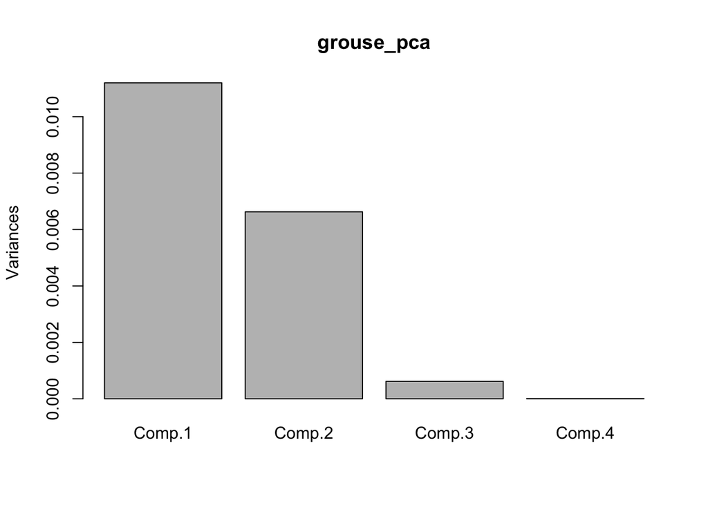

```r
df2 <- df[, 4:7]
grouse_pca <- princomp(df2)
plot(grouse_pca)
```

and the summary

```r
summary(grouse_pca)
```

```
## Importance of components:
##                           Comp.1     Comp.2     Comp.3       Comp.4
## Standard deviation     0.1058273 0.08141457 0.02489681 0.0027940421
## Proportion of Variance 0.6068366 0.35915399 0.03358643 0.0004230019
## Cumulative Proportion  0.6068366 0.96599057 0.99957700 1.0000000000
```

shows us that 95% of the variation is included in the first two components. We will use all 4 components and refit the models used above.

```r
df_pca <- as_data_frame(grouse_pca$scores)
df_pca$y <- df$y
globalMod_pca <- glm(y ~ Comp.1 + Comp.2 + Comp.3 + Comp.4, data = df_pca, na.action = na.fail, family=poisson())
fits <- dredge(globalMod_pca)
```

```
## Fixed term is "(Intercept)"
```

```r
model.sel(fits)
```

```
## Global model call: glm(formula = y ~ Comp.1 + Comp.2 + Comp.3 + Comp.4, family = poisson(),
##     data = df_pca, na.action = na.fail)
## ---
## Model selection table
##    (Intrc) Comp.1 Comp.2  Comp.3 Comp.4 df   logLik   AICc  delta weight
## 8   1.0070 -2.387 -12.11 -2.3040         4 -378.172  764.6   0.00  0.360
## 4   0.9983 -2.308 -12.43                 3 -379.224  764.6   0.02  0.356
## 16  1.0070 -2.379 -12.11 -2.3720  6.570  5 -378.025  766.4   1.81  0.146
## 12  0.9982 -2.300 -12.43          5.168  4 -379.133  766.5   1.92  0.138
## 3   1.0010        -13.06                 2 -401.104  806.3  41.72  0.000
## 11  1.0000        -13.07          9.769  3 -400.779  807.7  43.13  0.000
## 7   1.0050        -12.96 -0.6570         3 -401.022  808.2  43.62  0.000
## 15  1.0040        -12.95 -0.7617 10.200  4 -400.670  809.5  44.99  0.000
## 6   1.4070 -2.690        -7.4900         3 -663.456 1333.0 568.48  0.000
## 14  1.4070 -2.694        -7.4940  5.856  4 -663.338 1334.9 570.33  0.000
## 2   1.4250 -2.669                        2 -677.918 1359.9 595.35  0.000
## 10  1.4250 -2.672                 5.593  3 -677.812 1361.7 597.20  0.000
## 5   1.4470               -7.4800         2 -697.193 1398.4 633.90  0.000
## 13  1.4470               -7.4850  4.880  3 -697.112 1400.3 635.80  0.000
## 1   1.4640                               1 -711.512 1425.0 660.49  0.000
## 9   1.4640                        4.633  2 -711.439 1426.9 662.39  0.000
## Models ranked by AICc(x)
```

So it looks like the first two components are pretty much carrying all the water together, but not separately. We can confirm this by looking at the model averaged coefficients.

```r
summary(model.avg(fits))
```

```
##
## Call:
## model.avg(object = fits)
##
## Component model call:
## glm(formula = y ~ <16 unique rhs>, family = poisson(), data =
##      df_pca, na.action = na.fail)
##
## Component models:
##        df  logLik    AICc  delta weight
## 123     4 -378.17  764.55   0.00   0.36
## 12      3 -379.22  764.57   0.02   0.36
## 1234    5 -378.03  766.36   1.81   0.15
## 124     4 -379.13  766.47   1.92   0.14
## 2       2 -401.10  806.27  41.72   0.00
## 24      3 -400.78  807.68  43.13   0.00
## 23      3 -401.02  808.17  43.62   0.00
## 234     4 -400.67  809.54  44.99   0.00
## 13      3 -663.46 1333.03 568.48   0.00
## 134     4 -663.34 1334.88 570.33   0.00
## 1       2 -677.92 1359.90 595.35   0.00
## 14      3 -677.81 1361.75 597.20   0.00
## 3       2 -697.19 1398.45 633.90   0.00
## 34      3 -697.11 1400.35 635.80   0.00
## (Null)  1 -711.51 1425.04 660.49   0.00
## 4       2 -711.44 1426.94 662.39   0.00
##
## Term codes:
## Comp.1 Comp.2 Comp.3 Comp.4
##      1      2      3      4
##
## Model-averaged coefficients:
## (full average)
##              Estimate Std. Error Adjusted SE z value Pr(>|z|)
## (Intercept)   1.00273    0.05068     0.05099  19.666   <2e-16 ***
## Comp.1       -2.34578    0.35907     0.36127   6.493   <2e-16 ***
## Comp.2      -12.26722    0.62613     0.62976  19.479   <2e-16 ***
## Comp.3       -1.17513    1.62272     1.62765   0.722    0.470
## Comp.4        1.66930    6.98296     7.02007   0.238    0.812
##
## (conditional average)
##              Estimate Std. Error Adjusted SE z value Pr(>|z|)
## (Intercept)   1.00273    0.05068     0.05099  19.666   <2e-16 ***
## Comp.1       -2.34578    0.35907     0.36127   6.493   <2e-16 ***
## Comp.2      -12.26722    0.62613     0.62976  19.479   <2e-16 ***
## Comp.3       -2.32318    1.59331     1.60322   1.449    0.147
## Comp.4        5.88852   12.13112    12.20644   0.482    0.630
## ---
## Signif. codes:  0 '***' 0.001 '**' 0.01 '*' 0.05 '.' 0.1 ' ' 1
##
## Relative variable importance:
##                      Comp.2 Comp.1 Comp.3 Comp.4
## Importance:          1.00   1.00   0.51   0.28
## N containing models:    8      8      8      8
```

Now comes the hard part. What does that actually mean in terms of the original variables?

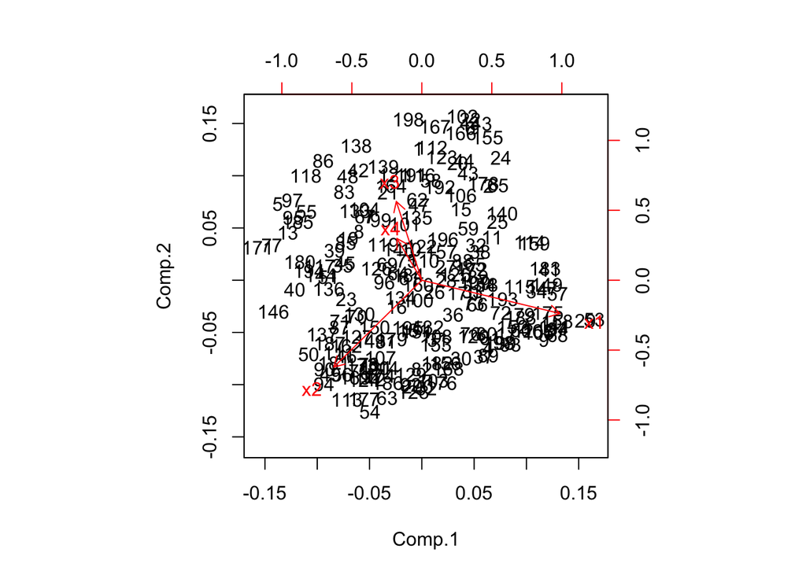

```r
biplot(grouse_pca)
```

So component 1 is “heavily loaded” on x1, and partially negative on x2. The arrow for x2 is not parallel to the x axis. The second component is mostly reflecting x3 and x4, but is partially negative of x2. Another way to see this is to look at the loadings directly

```r
grouse_pca$loadings
```

```
##
## Loadings:
##    Comp.1 Comp.2 Comp.3 Comp.4
## x1  0.824 -0.258        -0.501
## x3 -0.152  0.611 -0.598 -0.496
## x2 -0.525 -0.674 -0.141 -0.500
## x4 -0.149  0.324  0.787 -0.503
##
##                Comp.1 Comp.2 Comp.3 Comp.4
## SS loadings      1.00   1.00   1.00   1.00
## Proportion Var   0.25   0.25   0.25   0.25
## Cumulative Var   0.25   0.50   0.75   1.00
```

So the real hurdle is figuring out what those coefficients actually mean. Probably the best way would be to create a new data frame reflecting some set of possible changes in habitat proportions (appropriately constrained), using the loadings matrix to transform those into the PCA scores, and then using that for prediction.

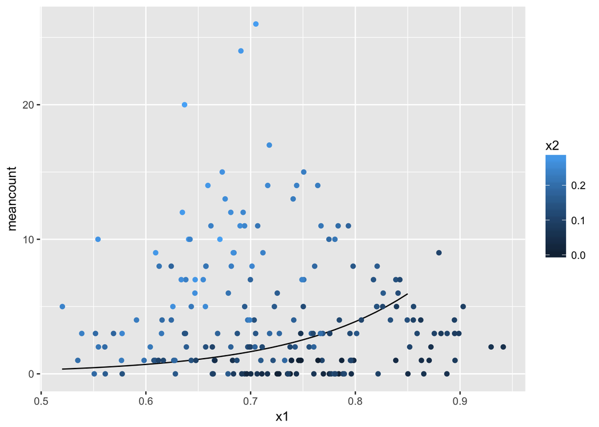

```r
nd <- data_frame(x1 = seq(0.52, 0.85, 0.01),
                 x2 = 0.15,
                 pos = x1 + x2,
                 x3 = pmax(1-pos,0),
                 x4 = pmax(1-pos-x3,0))
nd_pca <- as_data_frame(predict(grouse_pca, nd[,-3]))
predmodel <- get.models(fits, subset = 2)
preds <- cbind(nd,
               meancount = predict(predmodel[[1]], newdata=nd_pca, type = "response"))
ggplot(preds, aes(x = x1, y=meancount)) + geom_line() +
  geom_point(aes(x = x1, y = y, color = x2), data=df)
```

So, not trivial to figure out how to make predictions using these models. But seems to solve the issues.

### Isometric log ratio transformations

```r
library(robCompositions)
pivotCoord(as.data.frame(df2))
```

```
##     x1_x3-x2-x4     x3_x2-x4        x2_x4
## 1      1.696892  0.406795115 -0.599419445
## 2      2.212023  0.715335334 -0.618209390
## 3           Inf          Inf         -Inf
## 4           Inf         -Inf  1.874474784
## 5      1.093790 -0.126444462  0.342036142
## 6           Inf          Inf         -Inf
## 7      1.511748 -0.068840832  0.268578014
## 8      1.525855  0.113341337  0.646427273
## 9           Inf          NaN          Inf
## 10     1.767300 -0.130935386  0.490634834
## 11     2.142308 -0.127763354 -0.118029970
## 12          Inf         -Inf  1.217011189
## 13     1.212258 -0.092362757  0.606898004
## 14          Inf         -Inf  1.176853277
```

[output cut: 186 more lines]

So the problem is that this transformation can’t handle zeros. Hmmm. Ah! there are methods and functions for replacing the zero values.

```r
df2_replaced <- imputeBDLs(as.data.frame(df2), method="lm", dl = rep(0.005,4))
rowSums(df2_replaced$x)
```

```
##   [1] 0.9948197 0.9820074 1.0009241 0.9831023 0.9994395 0.9867955 0.9845969
##   [8] 0.9906198 0.9972511 0.9900944 0.9987780 0.9923572 0.9922242 1.0008749
##  [15] 0.9846555 0.9852303 0.9932009 0.9951165 0.9902566 0.9896986 0.9975160
##  [22] 0.9972525 0.9960855 0.9916167 0.9844309 0.9919495 0.9906275 0.9972389
##  [29] 0.9922829 0.9884130 0.9964684 0.9917504 0.9867707 0.9972258 0.9844735
##  [36] 0.9805525 0.9916489 0.9989472 0.9956154 0.9894367 0.9875068 0.9820721
##  [43] 0.9855530 0.9892684 0.9924536 0.9851235 0.9941226 0.9822141 0.9835819
##  [50] 0.9918425 0.9918048 1.0002033 0.9974146 1.0019294 0.9994742 0.9932838
##  [57] 0.9931162 0.9845155 0.9813092 0.9896406 0.9863332 0.9880988 0.9881330
##  [64] 0.9869391 0.9977576 0.9931315 0.9844152 0.9994895 0.9929361 0.9827264
##  [71] 0.9934290 0.9942892 0.9965469 0.9907341 0.9856205 0.9973709 0.9930109
##  [78] 0.9858968 0.9957601 0.9906338 0.9846673 0.9925985 0.9881256 0.9863439
##  [85] 0.9821127 0.9973090 0.9997119 0.9906794 0.9950435 0.9935998 0.9920138
##  [92] 0.9975535 0.9948968 0.9859085 0.9815540 0.9945455 0.9881978 0.9856648
##  [99] 0.9808004 0.9939879 0.9801199 0.9853975 0.9902716 0.9916401 0.9994026
## [106] 0.9806453 0.9934091 0.9982368 0.9918720 0.9852047 0.9836552 0.9975107
## [113] 0.9900145 0.9868832 0.9811204 0.9886037 0.9908731 0.9987423 0.9829855
## [120] 0.9938738 0.9999005 0.9842321 0.9870207 0.9874710 0.9918808 0.9842766
## [127] 0.9814868 0.9972797 0.9984739 0.9860158 0.9889223 0.9835037 0.9897252
## [134] 0.9859313 0.9910921 0.9892082 0.9990462 0.9956048 0.9989189 0.9920223
## [141] 0.9910309 0.9841838 0.9942990 0.9887754 0.9872468 0.9830852 0.9848464
## [148] 0.9901063 0.9977533 0.9871787 0.9950230 0.9826387 0.9924785 0.9976715
## [155] 0.9979133 0.9812221 0.9823395 0.9858231 0.9991800 0.9925933 0.9969300
## [162] 0.9988039 0.9866597 0.9990837 0.9949035 0.9887389 0.9839284 0.9989434
## [169] 0.9871145 0.9986722 0.9895750 0.9834894 0.9960609 0.9886110 0.9912785
## [176] 1.0015250 0.9846293 0.9983448 0.9933712 0.9976752 0.9971406 0.9915968
## [183] 0.9816703 0.9921239 0.9916327 1.0020797 0.9945973 0.9858946 0.9826928
## [190] 0.9944376 0.9897142 0.9907329 0.9873294 0.9952751 0.9824804 0.9944432
## [197] 1.0008764 0.9962166 0.9810454 0.9895596
```

```r
df2_ilr <- pivotCoord(df2_replaced$x)
df2_ilr$y <- df$y
globalMod_ilr <- glm(y ~ `x1_x3-x2-x4` +  `x3_x2-x4`  + `x2_x4`, data = df2_ilr, na.action = na.fail, family=poisson())
fits <- dredge(globalMod_ilr)
```

```
## Fixed term is "(Intercept)"
```

```r
model.sel(fits)
```

```
## Global model call: glm(formula = y ~ `x1_x3-x2-x4` + `x3_x2-x4` + x2_x4, family = poisson(),
##     data = df2_ilr, na.action = na.fail)
## ---
## Model selection table
##    (Int) `x1_x3-x2-x4` `x3_x2-x4`  x2_x4 df   logLik   AICc  delta weight
## 8 2.0330       -0.9653    -0.5350 0.9253  4 -411.087  830.4   0.00      1
## 6 1.3540       -0.3593            1.0230  3 -469.388  944.9 114.52      0
## 7 0.6903                  -0.1222 0.5691  3 -485.792  977.7 147.33      0
## 5 0.7561                          0.7160  2 -491.241  986.5 156.16      0
## 4 1.4500       -0.4504    -0.6712         3 -511.205 1028.5 198.15      0
## 3 0.7336                  -0.4222         2 -537.439 1078.9 248.56      0
## 2 0.4712        0.3871                    2 -652.323 1308.7 478.33      0
## 1 1.4640                                  1 -711.512 1425.0 594.66      0
## Models ranked by AICc(x)
```